# Food at College

```r
# From your file menu (at the top of R-Studio) select:
# "Session -> Set working directory -> To source file location"
# Then play this chunk to get the data into R.
library(mosaic)
library(car)
library(DT)
library(pander)
library(readr)
food <- read_csv("../../Data/food.csv")#food.csv is in the Data folder...
```

## Background

This data set was provided by my statistics class for further analysis. There were multiple questions asked to college students about their eating habits as well as an array of personal information.

Data Table

```r
library(ggplot2)
library(knitr)
library(tidyverse)
food <- food %>%
  mutate(real_cuisine = case_when(
    cuisine == 1 ~ "American",
    cuisine == 2 ~ "Mexican.Spanish",
    cuisine == 3 ~ "other",
    cuisine == 4 ~ "other",
    cuisine == 5 ~ "other",
    cuisine == 6 ~ "other",
  ))
#select the only columns we need
food2 <-select(food,c(weight, real_cuisine))

#get rid of the rows that are null
omit <- na.omit(food2)

#clean the weight column as it was sloppy and not considered a numeric column
omit$weight <- str_replace_all(omit$weight, c("lbs" = "", "Not sure," = "", ","= ""))
#filter out unneeded information
new_food <- omit %>%
  filter(weight != "I'm not answering this.")

#the weight column is still in a str type so I had to convert it back to numeric inorder to...
# be able to use it in further equations
new_food$weight <- as.numeric(new_food$weight)

datatable(new_food, options=list(lengthMenu = c(3,10,30),scrollY=300,scroller=TRUE,scrollX=TRUE),
            extensions="Scroller")
```

|  | weight | real_cuisine |
| --- | --- | --- |
| 1 | 155 | American |
| 2 | 240 | Mexican.Spanish |
| 3 | 190 | Mexican.Spanish |
| 4 | 180 | American |
| 5 | 137 | American |
| 6 | 180 | American |
| 7 | 125 | American |
| 8 | 116 | American |
| 9 | 110 | American |
| 10 | 264 | American |

[output cut: 96 more lines]

Although there are many attributes and columns we are only going to be looking at the weight and cuisine columns for the purpose of this analysis. In order to make this data more readable for our uses I created the real cuisine column that displays the type of cuisine which I coordinated with the number code that was accompanied by the data set. I also did some cleaning on the weights column to remove anything that wasn’t in numeric form like labels or options or anything excess. The weight column needed to be clean because the dirty data prevented any meaningful calculations from being made. Due to the lack of data for certain categories I grouped them into the other column.

## Analysis

### Graphical Representation

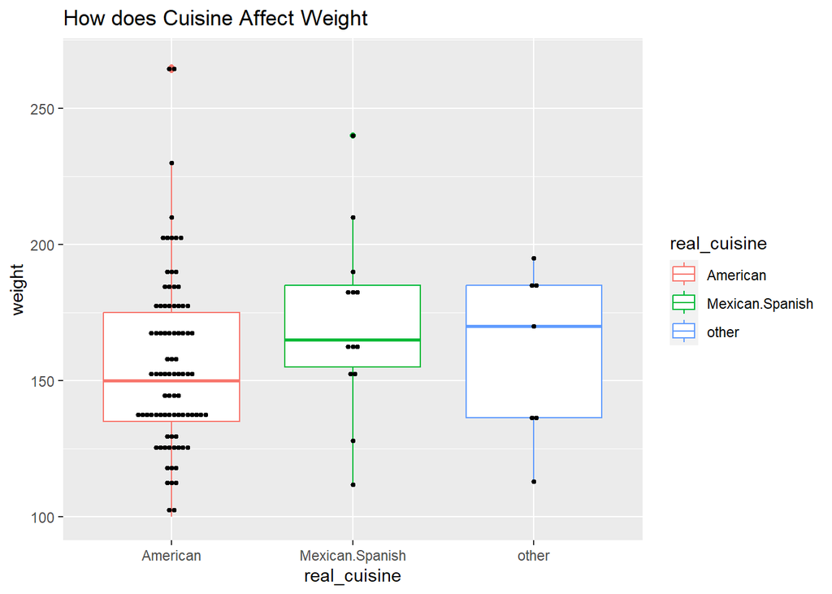

```r
p <- ggplot(new_food,aes(real_cuisine,weight))+
  geom_boxplot(aes(color=real_cuisine),position=position_dodge(width=0.5)) + labs(title= "How does Cuisine Affect Weight")
p + geom_dotplot(binaxis='y', stackdir='center',
                 position=position_dodge(1), dotsize = .3)
```

### Numerical Analysis

```r
new_food %>%
  group_by(real_cuisine)%>%
  summarise(Min = min(weight),
            Q1 = quantile(weight, 0.25),
            Mean = mean(weight),
            Median = median(weight),
            Q3 = quantile(weight, 0.75),
            Max = max(weight),
            "Standard Dev" = sd(weight),
            Num = n()) %>%
  pander()
```

| real_cuisine | Min | Q1 | Mean | Median | Q3 | Max | Standard Dev | Num |
| --- | --- | --- | --- | --- | --- | --- | --- | --- |
| American | 100 | 135 | 156.4 | 150 | 175 | 265 | 31.67 | 86 |
| Mexican.Spanish | 112 | 155 | 170.8 | 165 | 185 | 240 | 33.19 | 13 |
| other | 113 | 136.5 | 160.1 | 170 | 185 | 195 | 31.34 | 7 |

The summary table above will show another way to measure the center and spread of weight being grouped by the type of cuisine they grew up eating.

### Hypothesis

From looking at the examples above I want to see if what you eat when growing up has an affect on your weight. My null hypothesis is:

$$H_0: \text{All samples represent a sample of data from the same
distribution.}$$

$$H_a: \text{At least one distribution is stochastically different than
the others.}$$
Formally the level of significance for this test is
$$\alpha = 0.05$$

### Addressing Normality

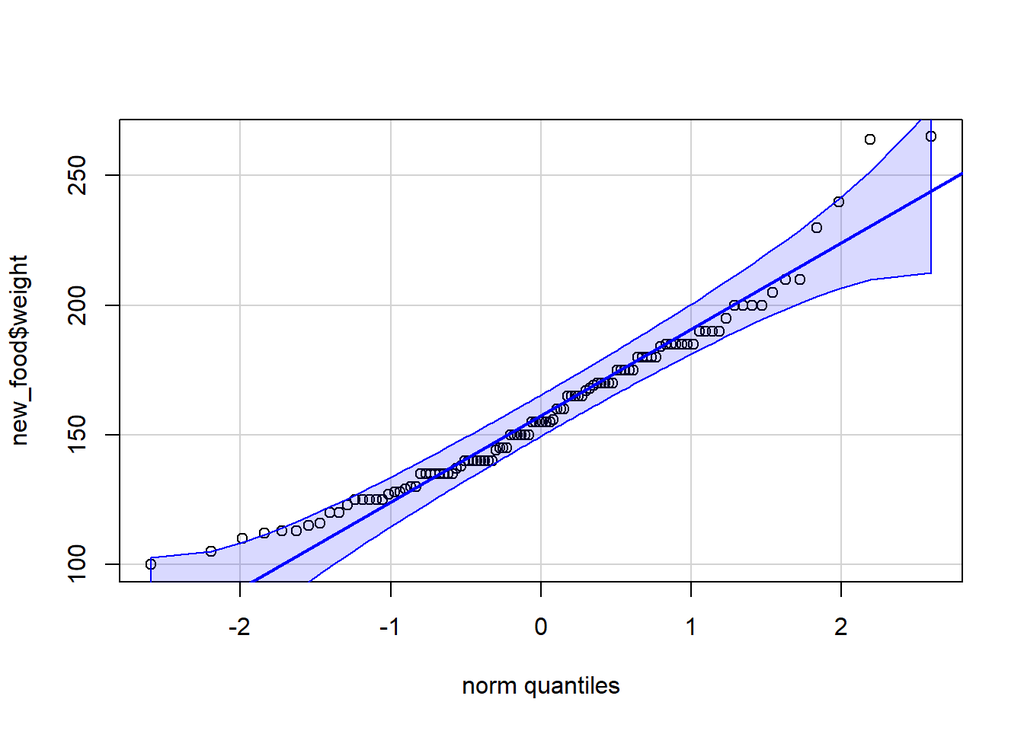

```r
qqPlot(new_food$weight, id=FALSE)
```

Looking at the QQ-plot above it does seem to show an acceptable amount of normality. To the extend of where I would feel comfortable using an ANOVA test rather than a Krukal-Wallis test as it doesn’t appear that a Non- parametric test is needed for this specific situation. Though this is true due to our requirements for this class project we are going to go ahead and use a Kruskal- Wallis test instead.

### Kruskal- Wallis

```r
kruskal.test(weight ~ real_cuisine, data=new_food)%>%
  pander()
```

Kruskal-Wallis rank sum test: `weight` by `real_cuisine`

| Test statistic | df | P value |
| --- | --- | --- |
| 2.691 | 2 | 0.2604 |

There is insufficient evidence to reject the null hypothesis that each of these represents a sample from the same distribution. We will continue to assume that all people that ate different cuisines growing up have the same weight distribution.

## Interpretation

Since all samples can be assumed to be from the same distribution, the type of cuisine you eat growing up has no apparent affect on weight. So in general certain cuisines you grow up eating don’t seem to affect your weight.